# Praca domowa 6

```python
from sklearn.datasets import fetch_olivetti_faces
from sklearn.decomposition import PCA
from sklearn.metrics import mean_squared_error
from skimage.transform import rotate
from skimage.exposure import equalize_adapthist, equalize_hist
from skimage.filters import gaussian

import seaborn as sns
import skimage
import matplotlib.pyplot as plt
import numpy as np
import pandas as pd
```

```python
X, y = fetch_olivetti_faces(return_X_y=True)
```

```
downloading Olivetti faces from https://ndownloader.figshare.com/files/5976027 to /root/scikit_learn_data
```

```python
X.shape
```

```
(400, 4096)
```

```python
def show_faces(face1, face2):
  face1, face2 = face1.reshape(64,64), face2.reshape(64,64)
  f, (ax1, ax2) = plt.subplots(nrows=1, ncols=2)
  ax1.imshow(face1, cmap='gray')
  ax2.imshow(face2, cmap='gray')
  ax1.set_xticks([])
  ax1.set_yticks([])
  ax2.set_xticks([])
  ax2.set_yticks([])
  plt.show()
```

```python
def show_compressed(faces, faces_decomp):
  cols=len(faces)
  f, (row1, row2) = plt.subplots(nrows=2, ncols=cols, figsize=(18,4))
  f.suptitle('Faces before and after PCA decomposition')
  for i in range(cols):
    face = faces[i].reshape(64,64)
    face_decomp = faces_decomp[i].reshape(64,64)
    row1[i].imshow(face, cmap='gray')
    row1[i].set_xticks([])
    row1[i].set_yticks([])
    row2[i].imshow(face_decomp, cmap='gray')
    row2[i].set_xticks([])
    row2[i].set_yticks([])
```

```python
def compress_show(face_indx, pca_ncomps):
  X_compressed = Olivetti_pca.fit_transform(X)
  X_decompressed = Olivetti_pca.inverse_transform(X_compressed)
  print(f"Compression rate is equal to: {X.shape[1]/X_compressed.shape[1]}")
  show_faces(X[face_index], X_decompressed[face_index])
  return X_compressed, X_decompressed, Olivetti_pca
```

```python
def decompose_rmse_show(transformed_faces):
  transformed_compressed = Olivetti_pca.transform(transformed_faces)
  transformed_decompressed = Olivetti_pca.inverse_transform(transformed_compressed)
  print(f"Total RMSE: {mean_squared_error(transformed_faces, transformed_decompressed, squared=False)}")
  rmse_list = []
  for f1, f2 in zip(transformed_faces, transformed_decompressed):
    rmse_list.append(mean_squared_error(f1, f2, squared=False))
  show_compressed(transformed_faces, transformed_decompressed)
  return rmse_list
```

```python
face_index = 11
pca_ncomponents = 0.8
Olivetti_pca = PCA(n_components=pca_ncomponents)
```

## Punkty 0, 1, 2

```
Compression rate is equal to: 151.7037037037037
```

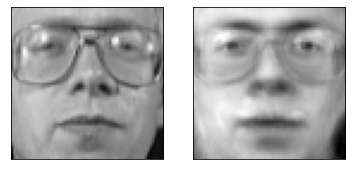

```python
X_comp, X_decomp, pca = compress_show(face_index, pca_ncomponents)
```

```
Total RMSE: 0.061369966715574265
```

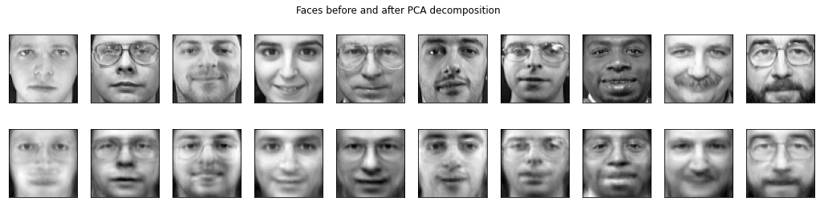

```python
basic_rmse = decompose_rmse_show(X[0:300:30])
```

## Punkt 3

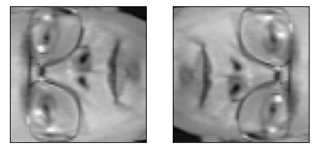

```python
face = X[face_index].reshape(64, 64)
f1 = rotate(face, angle=90)
f2 = rotate(face, angle=-90)
show_faces(f1, f2)
```

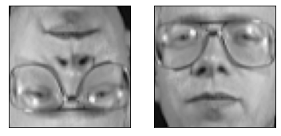

```python
f3 = np.flipud(face)
f4 = np.fliplr(face)
show_faces(f3, f4)
```

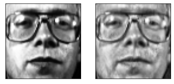

```python
f5 = equalize_hist(face)
f6 = equalize_adapthist(face)
show_faces(f5, f6)
```

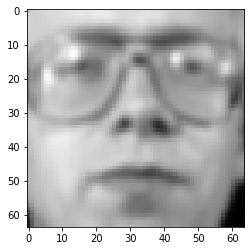

```python
f7 = gaussian(face)
plt.imshow(f7, cmap='gray')
plt.show()
```

## Punkt 4

```
Total RMSE: 0.1270323097705841
```

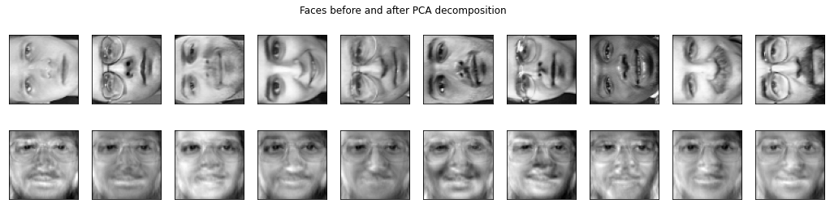

```python
rot_faces = np.array([rotate(X[i].reshape(64,64), angle=90).reshape(4096) for i in range(0,300,30)])
counter_rotation = decompose_rmse_show(rot_faces)
```

```
Total RMSE: 0.1277661919593811
```

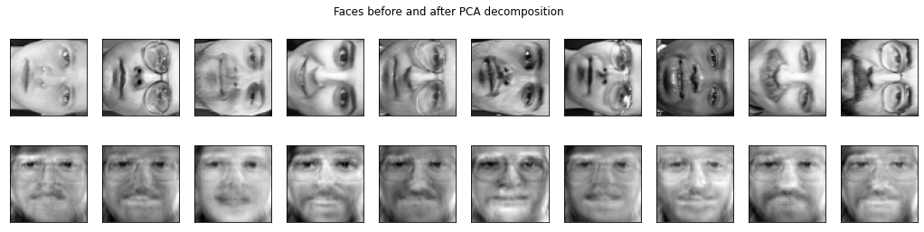

```python
rotated_faces = np.array([rotate(X[i].reshape(64,64), angle=-90).reshape(4096) for i in range(0,300,30)])
clock_rotation = decompose_rmse_show(rotated_faces)
```

```
Total RMSE: 0.12615589797496796
```

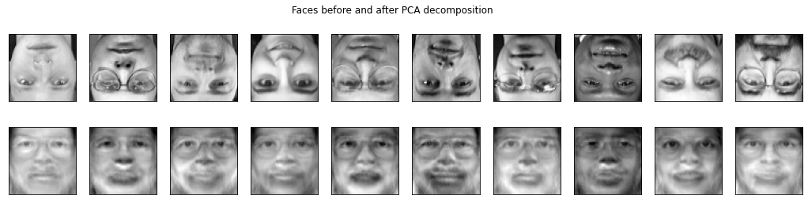

```python
vertflip_faces = np.array([np.flipud(X[i].reshape(64,64)).reshape(4096) for i in range(0,300,30)])
vertical_flip = decompose_rmse_show(vertflip_faces)
```

```
Total RMSE: 0.0768621638417244
```

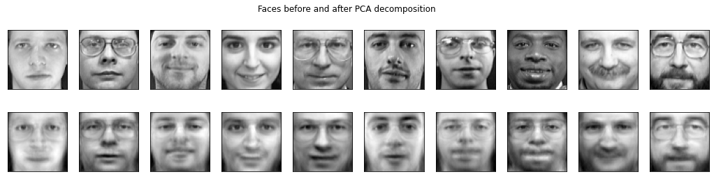

```python
horflip_faces = np.array([np.fliplr(X[i].reshape(64,64)).reshape(4096) for i in range(0,300,30)])
horizontal_flip = decompose_rmse_show(horflip_faces)
```

```
Total RMSE: 0.12538569066315491
```

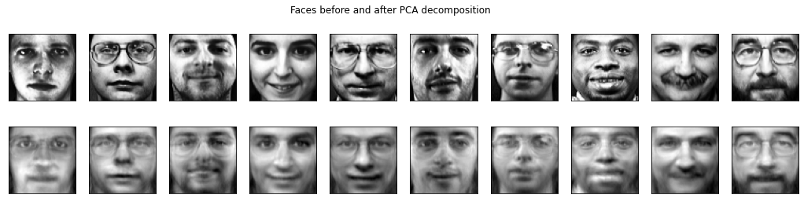

```python
shaded_faces = np.array([equalize_hist(X[i].reshape(64,64)).reshape(4096) for i in range(0,300,30)])
shaded_rmse = decompose_rmse_show(shaded_faces)
```

```
Total RMSE: 0.12385477557836523
```

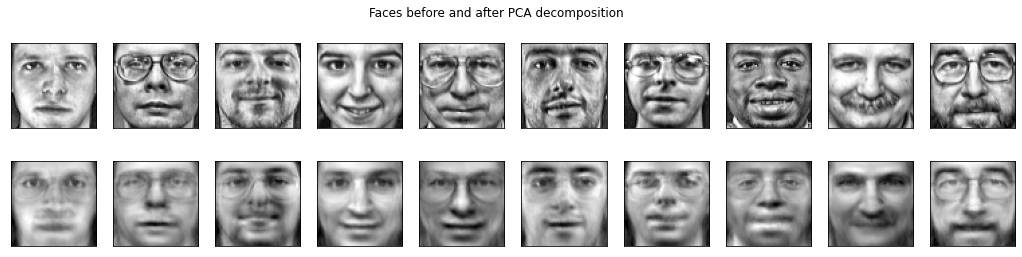

```python
shaded2_faces = np.array([equalize_adapthist(X[i].reshape(64,64)).reshape(4096) for i in range(0,300,30)])
shaded2_rmse = decompose_rmse_show(shaded2_faces)
```

```
Total RMSE: 0.045448336750268936
```

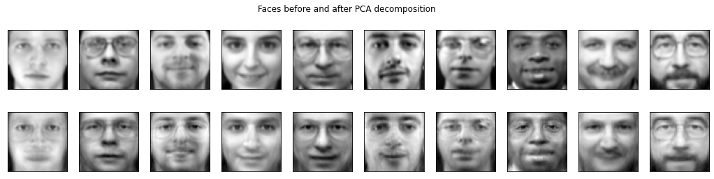

```python
blurred_faces = np.array([gaussian(X[i].reshape(64,64)).reshape(4096) for i in range(0,300,30)])
blur_rmse = decompose_rmse_show(blurred_faces)
```

## Punkt 5

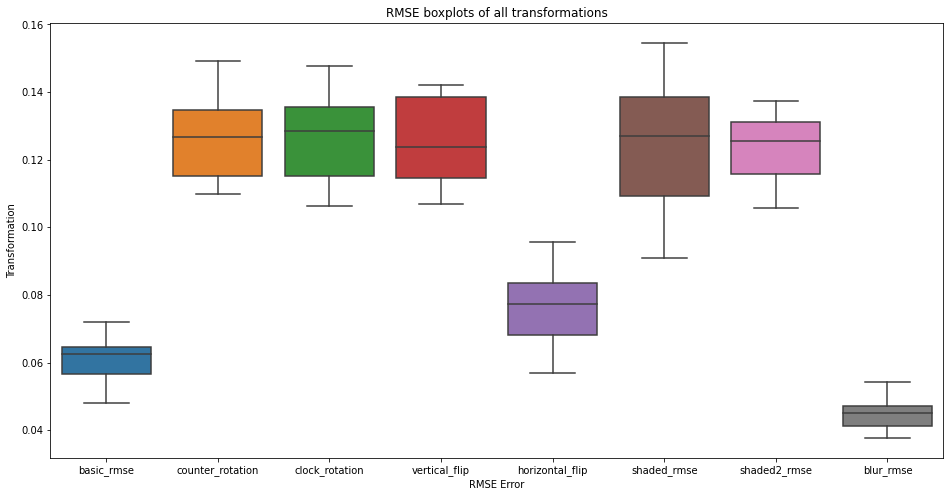

```python
cols = ['basic_rmse', 'counter_rotation', 'clock_rotation', 'vertical_flip',
        'horizontal_flip', 'shaded_rmse', 'shaded2_rmse', 'blur_rmse']
data = pd.DataFrame(zip(basic_rmse, counter_rotation, clock_rotation,
                        vertical_flip ,horizontal_flip, shaded_rmse,
                        shaded2_rmse, blur_rmse),
                    columns = cols)
plt.figure(figsize=(16, 8))
plt.title('RMSE boxplots of all transformations')
plt.xlabel('RMSE Error')
plt.ylabel('Transformation')
sns.boxplot(data=data)
plt.show()
```

Jak widzimy na powyzszych boxplotach, w zaleznosci od transformacji błąd rmse na obrazie twarzy znacznie sie różni od siebie.

Najpierw chciałbym zauważyć odwrotny od spodziewanego wyniku, bład na transformacji 'blur', czyli rozmyciu. Bład jest mniejszy niż błąd na podstawowych twarzach. Jednak po zastanowieniu sie, ma to sens. PCA zmniejsza wyrazistosc obrazw, tracac na dokładności. Troche przypomina to blur. Jednak na juz rozmytym obrazie efekt bedzie ten mniejszy, wiec lepszy wynik rmse.

Dla reszty transformacji błąd rmse był znacznie wyższy od błędu na nietransformowanych twarzach. Oznacza to że w ten sposób moglibyśmy wykrywać na przykładzie twarzy czy zdjęcia są w jakimś stopniu obrócone, zmienione. Po PCA obrazy kompletnie nie przypominają wczesniejszych obroconych wersji.

Jedynym wzglednie podobnym do pierwotego wyniku jest blad na "horizontal flip", czyli odbiciu lustrzanym. Oczywiście jest to sensowne, ponieważ twarze ludzkie są zazwyczaj w miarę symetryczne.

Dodatkowo pragne zauwazyc ze wszyscy po pca dostaja jakby delikatny zarys okularow, a twarze damskie stają się bardziej męskie. Wynikaja zapewne te rzeczy z znacznej ilosci mężczyzn i osób w okularch w tym dataset'cie.